# TOD Evaluation in Chicago

Yihong Hu 9/23/2021

# Introduction

Transit Oriented Development (TOD) has received much attention in the field of urban planning. Ideally, this planning model entails a more dense, walkable, sustainable city; nevertheless, some criticizes that the model will make housing prices spike, displacing residents in poor neighborhoods. This brief evaluates the effect and potential of TOD in Chicago, a large American city with a mature transit system. How had the demographics changed within potential TOD areas in ten years? What’s the relationship between these areas, rent and poverty rate? Are people willing to pay more for houses and rents near these areas?

This brief compares the data from 2009 and 2019. The year 2009 is chosen, because some data is only available starting from 2009. A period of ten years provides a long enough time frame to see changes. Since the most recent data has been updated in 2019, the data set also reflects a more accurate situation close to the year we are in now (2021).

# Data Wrangling

## Loading Functions and Formula

```r
library(tidyverse)
library(tidycensus)
library(sf)
library(kableExtra)
library(rmarkdown)
library(ggplot2)

options(scipen=999)
options(tigris_class = "sf")

mapTheme <- function(base_size = 12) {
  theme(
    text = element_text( color = "black"),
    plot.title = element_text(size = 16,colour = "black"),
    plot.subtitle=element_text(face="italic"),
    plot.caption=element_text(hjust=0),
    axis.ticks = element_blank(),
    panel.background = element_blank(),axis.title = element_blank(),
    axis.text = element_blank(),
    axis.title.x = element_blank(),
    axis.title.y = element_blank(),
    panel.grid.minor = element_blank(),
    panel.border = element_rect(colour = "black", fill=NA, size=2),
    strip.text.x = element_text(size = 14))
}

plotTheme <- function(base_size = 12) {
  theme(
    text = element_text( color = "black"),
    plot.title = element_text(size = 16,colour = "black"),
    plot.subtitle = element_text(face="italic"),
    plot.caption = element_text(hjust=0),
    axis.ticks = element_blank(),
    panel.background = element_blank(),
    panel.grid.major = element_line("grey80", size = 0.1),
    panel.grid.minor = element_blank(),
    panel.border = element_rect(colour = "black", fill=NA, size=2),
    strip.background = element_rect(fill = "grey80", color = "white"),
    strip.text = element_text(size=12),
    axis.title = element_text(size=12),
    axis.text = element_text(size=10),
    plot.background = element_blank(),
    legend.background = element_blank(),
    legend.title = element_text(colour = "black", face = "italic"),
    legend.text = element_text(colour = "black", face = "italic"),
    strip.text.x = element_text(size = 14)
  )
}

qBr <- function(df, variable, rnd) {
  if (missing(rnd)) {
    as.character(quantile(round(df[[variable]],0),
                          c(.01,.2,.4,.6,.8), na.rm=T))
  } else if (rnd == FALSE | rnd == F) {
    as.character(formatC(quantile(df[[variable]]), digits = 3),
                 c(.01,.2,.4,.6,.8), na.rm=T)
  }
}

qBr2 <- function(df, variable, rnd) {
  if (missing(rnd)) {
    as.character(quantile(round(df[[variable]],digits = 2),
                          c(.01,.2,.4,.6,.8), na.rm=T))
  } else if (rnd == FALSE | rnd == F) {
    as.character(formatC(quantile(df[[variable]]), digits = 3),
                 c(.01,.2,.4,.6,.8), na.rm=T)
  }
}

q5 <- function(variable) {as.factor(ntile(variable, 5))}
q7 <- function(variable) {as.factor(ntile(variable, 7))}
q4 <- function(variable) {as.factor(ntile(variable, 4))}

palette5 <- c("#f0f9e8","#bae4bc","#7bccc4","#43a2ca","#0868ac")
palette6 <- c("#00FFCC","#00FF99","#00FF66","#00FF33","#003300")
```

## Activate API key

```r
census_api_key("94efffd19b56ad527e379faea1653ee74dc3de4a",overwrite = TRUE)
```

## Getting ACS Data of Chicago from 2009 and 2019

The shapefile for Chicago, using “place” feature, is missing. The map for Cook County is used instead to display the L-train stops in Chicago.

Chicago ACS Data 2009

```r
Chicago_09 <-
  get_acs(geography = "tract", output = "wide", variables = c(Total_Pop = "B25026_001E",White_Pop = "B02001_002E",Female_Bach = "B15001_050E", Male_Bach = "B15001_009E",MedHHInc = "B19013_001E",Med_Rent = "B25058_001E", Poverty_Pop = "B06012_002E"),
                year=2009, state=17, county = 31, geometry=T) %>%
  st_transform('EPSG:26916')

Chicago_09 <- Chicago_09 %>%
  dplyr::select(-NAME,-ends_with("M"),-geometry)%>%
  mutate(pctWhite = ifelse(Total_Pop > 0, White_Pop / Total_Pop, 0),
  pctBachelors = ifelse(Total_Pop > 0, ((Female_Bach + Male_Bach) / Total_Pop), 0),
         pctPoverty = ifelse(Total_Pop > 0, Poverty_Pop / Total_Pop, 0),
         year = "2009") %>%
  dplyr::select(-White_Pop,-Female_Bach,-Male_Bach,-Poverty_Pop)
```

## Chicago ACS Data 2019

```r
Chicago_19 <-
  get_acs(geography = "tract", output = "wide", variables = c(Total_Pop = "B25026_001E",White_Pop = "B02001_002E",Female_Bach = "B15001_050E", Male_Bach = "B15001_009E",MedHHInc = "B19013_001E",Med_Rent = "B25058_001E", Poverty_Pop = "B06012_002E"),
                year=2019, state=17, county=31, geometry=T) %>%
  st_transform('EPSG:26916')

Chicago_19 <- Chicago_19 %>%
  dplyr::select(-NAME,-ends_with("M"),-geometry)%>%
  mutate(pctWhite = ifelse(Total_Pop > 0, White_Pop / Total_Pop, 0),
  pctBachelors = ifelse(Total_Pop > 0, ((Female_Bach + Male_Bach) / Total_Pop), 0),
         pctPoverty = ifelse(Total_Pop > 0, Poverty_Pop / Total_Pop, 0),
         year = "2019") %>%
  dplyr::select(-White_Pop,-Female_Bach,-Male_Bach,-Poverty_Pop)
```

## Combining 2009 and 2019 Data

```r
Chicago_09and19 <- rbind(Chicago_09,Chicago_19)
```

## Getting Transit Open Data

Chicago transit data can be found on Chicago Transit Authority website. We download the point-level data for L train stops in this case.

```r
Chicago_L_Stops <-
  st_read("https://data.cityofchicago.org/download/4qtv-9w43/application%2Fxml") %>%
  mutate(Stops = "Stops") %>%
  st_transform('EPSG:26916')

#Change the coordinator system to show locations in coordinates instead of latitude and longitude. This set-up will be easier for future use. The lenth  unit is meter.
```

## Visualize L Train Stops in Chicago

Figure 1 below shows the location of the L train stops at a point-level.

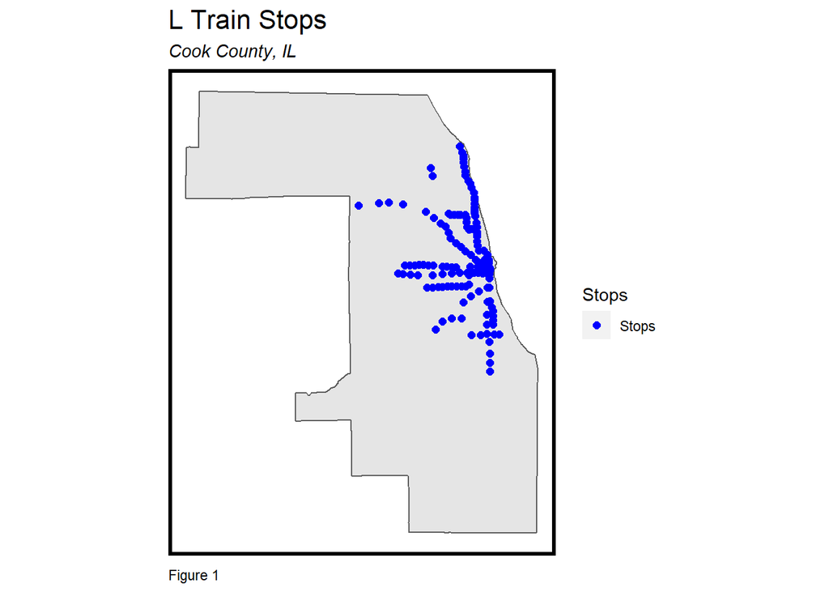

```r
ggplot() +
  geom_sf(data=st_union(Chicago_09)) +
  geom_sf(data = Chicago_L_Stops,
          aes(colour=Stops),
          show.legend = "point", size= 2) +
  scale_colour_manual(values = ("blue")) +
  labs(title="L Train Stops",
       subtitle="Cook County, IL",
       caption="Figure 1") +
  mapTheme()
```

## Setting-up Buffers for L Stops

Graph below shows the buffer zone 1/2 miles in radius around L train stops.

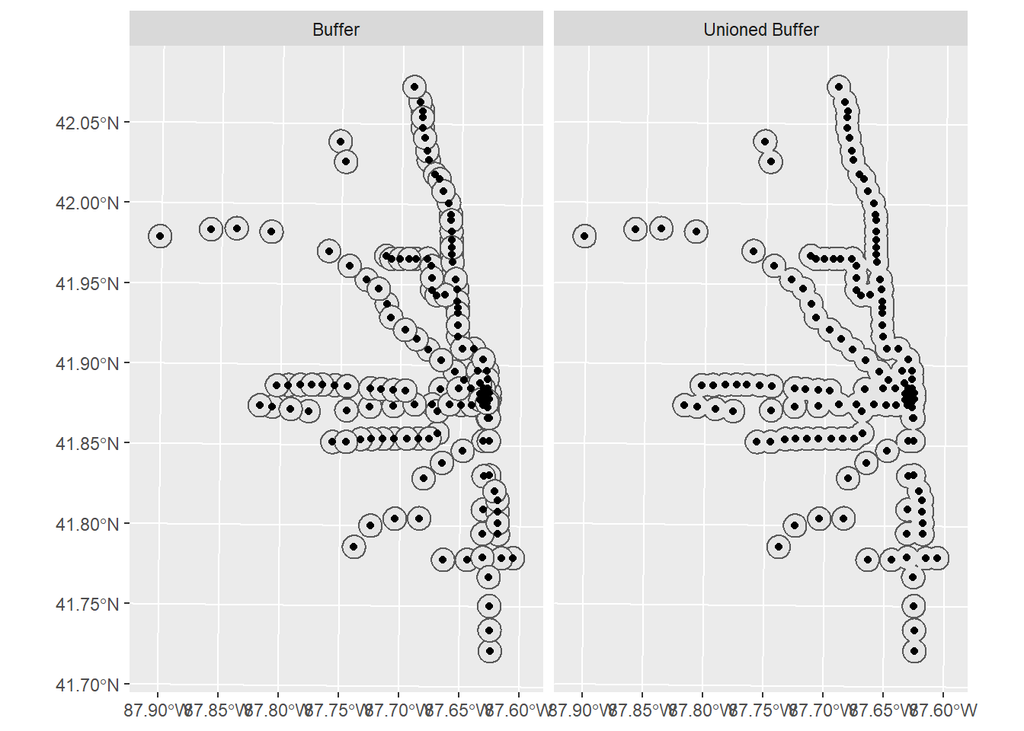

```r
LBuffers <-
  rbind(
    st_buffer(Chicago_L_Stops, 800) %>%
      mutate(Legend = "Buffer") %>%
      dplyr::select(Legend),
    st_union(st_buffer(Chicago_L_Stops, 800)) %>%
      st_sf() %>%
      mutate(Legend = "Unioned Buffer")) %>%
    st_transform('EPSG:26916')

ggplot() +
  geom_sf(data=LBuffers) +
  geom_sf(data=Chicago_L_Stops, show.legend = "point") +
  facet_wrap(~Legend) + scale_color_manual(values="blue")
```

```r
  mapTheme()
```

## Selecting the intersectional space between buffer and Chicago

```r
buffer <- filter(LBuffers, Legend=="Unioned Buffer")

Centroids <-
  st_centroid(Chicago_19)[buffer,] %>%
    st_drop_geometry() %>%
    left_join(dplyr::select(Chicago_19, GEOID)) %>%
    st_sf()
```

# Time/Space Analysis between 2009 - 2019 for TOD and non-TOD Areas

We want to conduct this analysis in Chicago only, otherwise non-TOD areas will extend to suburbs. In the steps below, a Chicago map in selected out by census tracts.

## Separating TOD and Non TOD data and Loading Variable Information

```r
Chicago_09and19.TODinfo <-
  rbind(
    st_centroid(Chicago_09and19)[buffer,] %>%
      st_drop_geometry() %>%
      left_join(Chicago_09and19) %>%
      st_sf() %>%
      mutate(TOD = "TOD"),
    st_centroid(Chicago_09and19)[buffer, op = st_disjoint] %>%
      st_drop_geometry() %>%
      left_join(Chicago_09and19) %>%
      st_sf() %>%
      mutate(TOD = "Non-TOD")) %>%
  mutate(Med_Rent.inf = ifelse(year == "2009", Med_Rent * 1.22, Med_Rent))%>%
  mutate(MedHHInc.inf = ifelse(year=="2009",MedHHInc * 1.22, MedHHInc))%>%
  mutate(pctPoverty.inf = pctPoverty*100, pctPoverty)%>%
  mutate(pctBachelors.inf = pctBachelors*100, pctBachelors)%>%
  st_transform('EPSG:26916')
```

## Clip-out Chicago from Cook County

```r
Chicago_Census_Tract_B <- st_read("https://data.cityofchicago.org/api/geospatial/5jrd-6zik?method=export&format=GeoJSON")%>%
  st_transform(st_crs(Chicago_09and19.TODinfo))

Chicago_selected <- Chicago_09and19.TODinfo[Chicago_Census_Tract_B,]
```

## Time/Space Graph Grouped by TOD and Non TOD areas

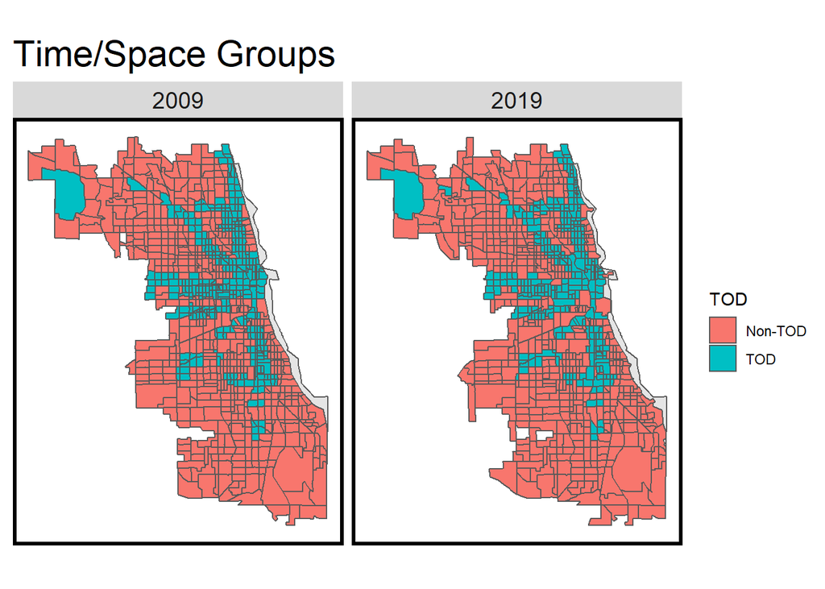

```r
 ggplot(Chicago_selected)+
    geom_sf(data = st_union(Chicago_Census_Tract_B))+
    geom_sf(aes(fill = TOD)) +
    labs(title = "Time/Space Groups") +
    facet_wrap(~year)+
    mapTheme() +
    theme(plot.title = element_text(size=22))
```

We could see that Chicago census tracts generally remained the same, with a little expansion in 2019.

We can then plot Time/Space Analysis Plots across different variables.